On this page

# Visualize data on Nobel laureates per country

*2020-10-18*

The Nobel laureates of 2020 were announced last week, and I thought it would be interesting to visualize the repartition of laureates per country, as there are several ways to do so. I’m going to use [this dataset](https://www.kaggle.com/nobelfoundation/nobel-laureates) available on Kaggle, which contains information on the year, category, name of the laureate, country, city and date of birth and death, among other things. Notice that this dataset goes from 1901 to 2016 and therefore doesn’t contain the most recent laureates.

But first of all, we need to load all the packages we will use in this analysis:

```
library(tidyverse)
library(janitor)
library(ggthemes)
library(gganimate)
library(here)
library(tmap)
library(countrycode)
library(echarts4r)
```

## Import and clean data

Now, we can import the dataset. To remove the capital letters and transform the column names in snake case (i.e names such as “column_name” instead of “Column Name”), we can use the function `clean_names()` of the package `{janitor}` 1This function is very useful even when column names are much more messy.:

```
nobel_laureates_raw <- read_csv("nobel-laureates.csv") %>%
  janitor::clean_names()
```

The first thing that we have to correct before doing visualization concerns the country names. Indeed, many countries have changed since 1901. For example, Czechoslovakia no longer exists, as well as Prussia. In this dataset, the columns containing country names display first the official name at the time, and then put the current name of the country between brackets.

```
# A tibble: 6 × 2
  birth_country     death_country
  <chr>             <chr>
1 Netherlands       Germany
2 France            France
3 Prussia (Poland)  Germany
4 Switzerland       Switzerland
5 France            France
6 Prussia (Germany) Germany
```

Since we only want the current country names, we must modify these columns so that:

- if the name doesn’t have brackets (i.e the country hasn’t changed in time), we let it as-is;
- if the name has brackets (i.e the country has changed), we only want to keep the name between brackets.

Since I must do this for two columns (`birth_country` and `death_country`), I created a function (and this was the perfect example of losing way too much time by making a function to save time…):

```
clean_country_names <- function(data, variable) {
  data <- data %>%
    mutate(
      x = gsub(
        "(?<=\\()[^()]*(?=\\))(*SKIP)(*F)|.",
        "",
        {{variable}},
        perl = T
      ),
      x = ifelse(x == "", {{variable}}, x)
    ) %>%
    select(- {{variable}}) %>%
    rename({{variable}} := "x")
}
```

This function takes a dataset (`data`), and creates a new column (`x`) that will take the name between brackets if original variable has brackets, or the unique name if the original variable doesn’t have brackets. Then, `x` is renamed as the variable we specified first. I must admit that regular expressions (such as the one in `gsub()`) continue to be a big mystery for me, and I thank StackOverflow for providing many examples.

Now, we apply this function to our columns with countries:

```
nobel_laureates <- clean_country_names(nobel_laureates_raw, birth_country)
nobel_laureates <- clean_country_names(nobel_laureates, death_country)
```

The country names are now cleaned:

```
# A tibble: 6 × 2
  birth_country death_country
  <chr>         <chr>
1 Netherlands   Germany
2 France        France
3 Poland        Germany
4 Switzerland   Switzerland
5 France        France
6 Germany       Germany
```

From now on, there are several ways to visualize the repartition of Nobel laureates per country. We could do a static bar plot, an animated bar plot to see the evolution in time, a static map, or an interactive map.

## Plot the data

### Static plot

First of all, we need to compute the number of Nobel laureates per country:

```
nobel_per_country <- nobel_laureates %>%
  select(birth_country, full_name) %>%
  distinct() %>%
  group_by(birth_country) %>%
  count(sort = TRUE) %>%
  ungroup() %>%
  drop_na()
```

Then we can plot this number, only for the first 20 countries (so that the plot can be readable):

```
nobel_per_country %>%
  select(birth_country, n) %>%
  top_n(20) %>%
  mutate(birth_country = reorder(birth_country, n)) %>%
  ggplot(aes(x = birth_country, y = n)) +
  geom_col() +
  coord_flip() +
  xlab("Country") +
  ylab("") +
  geom_text(aes(label = n), nudge_y = 10) +
  ggthemes::theme_clean()
```

[figure not shown]

We can also check the repartition per country and per category:

```
# The 20 countries with the most nobels
top_20 <- nobel_per_country %>%
  top_n(10) %>%
  select(birth_country) %>%
  unlist(use.names = FALSE)

nobel_laureates %>%
  select(birth_country, full_name, category) %>%
  distinct() %>%
  group_by(birth_country, category) %>%
  mutate(n = n()) %>%
  ungroup() %>%
  drop_na() %>%
  select(- full_name) %>%
  distinct() %>%
  filter(birth_country %in% top_20) %>%
  ggplot(aes(x = birth_country, y = n)) +
  geom_col() +
  coord_flip() +
  xlab("Country") +
  ylab("") +
  geom_text(aes(label = n), nudge_y = 10) +
  ggthemes::theme_clean() +
  facet_wrap(~category)
```

[figure not shown]

### Animated plots

To observe the evolution of this number in time, one way would be to plot lines with `year` in x-axis. But we could also keep the first plot we made and animate it with `{gganimate}`.

First, we compute the cumulated sum of Nobel laureates. Indeed, the number of laureates per year is useless for us, we want to see the evolution of the total number:

```
nobel_per_country_year <- nobel_laureates %>%
  select(year, birth_country) %>%
  group_by(year, birth_country) %>%
  count(sort = TRUE) %>%
  ungroup() %>%
  drop_na() %>%
  arrange(birth_country, year) %>%
  complete(year, birth_country) %>%
  mutate(n = ifelse(is.na(n), 0, n),
         year = as.integer(year)) %>%
  filter(birth_country %in% top_20) %>%
  group_by(birth_country) %>%
  mutate(n_cumul = cumsum(n)) %>%
  arrange(birth_country)
```

Then, we use almost the same code as for the first plot, but we add arguments at the end that tell how we want the animation to be:

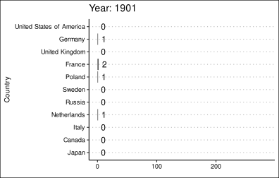

```
plot_evol <- nobel_per_country_year %>%
  select(birth_country, year, n_cumul) %>%
  filter((year %% 2) != 0) %>%
  ggplot(aes(x = reorder(birth_country, n_cumul), y = n_cumul)) +
  geom_col() +
  coord_flip() +
  xlab("Country") +
  ylab("") +
  geom_text(aes(label = as.character(round(n_cumul, 0))), nudge_y = 10) +
  ggthemes::theme_clean() +
  transition_time(year) +
  ggtitle("Year: {frame_time}") +
  ease_aes('linear', interval = 2)

animate(plot_evol, duration = 15, fps = 20)
```

This allows us to see that the USA have seen their number of Nobel laureates surge from the 1960′s and 1970′s, which corresponds more or less to the creation of the so-called “Nobel Prize in Economics” in 1969. The plot per category also indicates that this prize plays a major role in the domination of the USA.

## Maps

### Static maps

To create maps, we rely on the package `{tmap}`. In addition to its functions, this package also gives access to a dataset that we will use to show the number of laureates per country.

```
data(World)
```

We need to merge our dataset of Nobel laureates with this dataset. But the country names differ. Therefore, we have to use ISO codes instead. `World` already contains ISO codes, so we only have to create those for our dataset. This can be done very easily with the package `{countrycode}`. However, some countries in our dataset don’t have ISO codes, such as Scotland, Northern Ireland or Czechoslovakia. The two former can be recoded as United Kingdom, but Czechoslovakia was located on current Slovakia, Czech Republic and Ukraine, so we drop it of our dataset.

```
nobel_per_country <- nobel_per_country %>%
  mutate(
    iso_birth = countrycode(birth_country, origin = "country.name", destination = "iso3c"),
    iso_birth = case_when(
      birth_country == "Scotland" | birth_country == "Northern Ireland" ~ "GBR",
      TRUE ~ iso_birth
    )
  )
```

We can now merge the two datasets based on their ISO codes…

```
World <- World %>%
  full_join(nobel_per_country, by = c("iso_a3" = "iso_birth")) %>%
  rename("number" = "n") %>%
  mutate(number = ifelse(is.na(number), 0, number))
```

… and we can build the map and fill the countries with the number of laureates:

```
tm_shape(World, crs = 4326) +
  tm_polygons(fill = "number", fill.scale = tm_scale_intervals(
    breaks = c(0, 5, 10, 50, 200, Inf),
    values = "YlOrBr"
  )) +
  tm_legend(title = "Nobel prizes per country", legend.title.size = 10^(-4)) +
  tm_layout(legend.outside = TRUE)
```

[figure not shown]

### Interactive maps

Finally, we will make interactive maps with `{echarts4r}`. Firstly, let’s make an identical map as the one above but with a few interactive features.

`{echarts4r}` uses specific country names, so we use once again `{countrycode}` to modify the names in our dataset.

```
nobel_per_country_echarts <- e_country_names(data = nobel_per_country,
                                             input = iso_birth,
                                             type = "iso3c")
```

Now we can plot the map:

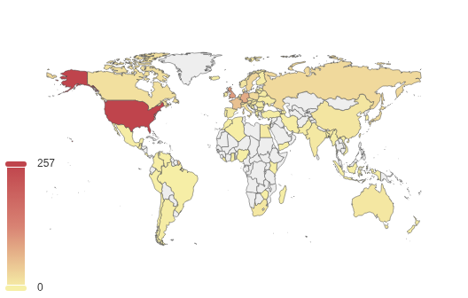

```
nobel_per_country_echarts %>%
  e_charts(iso_birth) %>%
  e_map(n, roam = TRUE) %>%
  e_visual_map(max = max(nobel_per_country_echarts$n))
```

Hovering the countries gives us their name, and the number of laureates in the legend. We can also zoom in and out. We could see the evolution of laureates in time with `timeline = TRUE`:

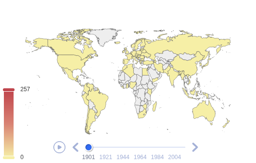

```
nobel_per_country_year_map <- nobel_laureates %>%
  select(year, birth_country) %>%
  group_by(year, birth_country) %>%
  count(sort = TRUE) %>%
  ungroup() %>%
  drop_na() %>%
  arrange(birth_country, year) %>%
  complete(year, birth_country) %>%
  mutate(n = ifelse(is.na(n), 0, n),
         year = as.integer(year)) %>%
  group_by(birth_country) %>%
  mutate(n_cumul = cumsum(n)) %>%
  arrange(birth_country)

nobel_per_country_year_map <- nobel_per_country_year_map %>%
  mutate(
    iso_birth = countrycode(birth_country, origin = "country.name", destination = "iso3c"),
    iso_birth = case_when(
      birth_country == "Scotland" | birth_country == "Northern Ireland" ~ "GBR",
      TRUE ~ iso_birth
    )
  )

nobel_per_country_year_echarts <- e_country_names(data = nobel_per_country_year_map,
                                                  input = iso_birth,
                                                  type = "iso3c")

nobel_per_country_year_echarts %>%
  group_by(year) %>%
  e_charts(iso_birth, timeline = TRUE) %>%
  e_map(n_cumul, roam = TRUE) %>%
  e_visual_map(max = 257) %>%
  e_timeline_opts(
    playInterval = 250,
    symbol = "none"
  )
```

And that’s it! I used data about Nobel laureates to present a few plots and maps made with `{ggplot2}`, `{gganimate}`, `{tmap}`, and `{echarts4r}`. I used these packages but there are countless ways to make plots or maps, whether static or interactive, with R:

- plots: base R, `{highcharter}`, `{charter}`, `{plotly}`, etc.
- maps: base R, `{leaflet}`, `{sf}`, `{ggmap}`, etc.

I hope you enjoyed it!

**Session Info**

This is my session info, so that you can see the versions of packages used. This is useful if the results in my post are no longer reproducible because packages changed. The packages with a star are those explicitely called in the script.

```
─ Session info ───────────────────────────────────────────────────────────────
 setting  value
 version  R version 4.5.0 (2025-04-11)
 os       Ubuntu 24.04.4 LTS
 system   x86_64, linux-gnu
 ui       X11
 language (EN)
 collate  en_US.UTF-8
 ctype    en_US.UTF-8
 tz       Europe/Paris
 date     2026-03-03
 pandoc   3.6.3 @ /usr/share/positron/resources/app/quarto/bin/tools/x86_64/ (via rmarkdown)
 quarto   1.9.27 @ /opt/quarto/bin/quarto

─ Packages ───────────────────────────────────────────────────────────────────
 package        * version    date (UTC) lib source
 abind            1.4-8      2024-09-12 [1] RSPM
 base64enc        0.1-6      2026-02-02 [1] RSPM
 bit              4.6.0      2025-03-06 [1] RSPM
 bit64            4.6.0-1    2025-01-16 [1] RSPM
 chromote         0.5.1      2025-04-24 [1] RSPM
 class            7.3-23     2025-01-01 [2] CRAN (R 4.5.0)
 classInt         0.4-11     2025-01-08 [1] RSPM
 cli              3.6.5      2025-04-23 [1] RSPM (R 4.5.0)
 codetools        0.2-20     2024-03-31 [2] CRAN (R 4.5.0)
 colorspace       2.1-2      2025-09-22 [1] RSPM (R 4.5.0)
 cols4all         0.10       2025-10-27 [1] RSPM
 countrycode    * 1.6.1      2025-03-31 [1] RSPM
 crayon           1.5.3      2024-06-20 [1] RSPM
 crosstalk        1.2.2      2025-08-26 [1] RSPM (R 4.5.0)
 data.table       1.18.2.1   2026-01-27 [1] RSPM
 DBI              1.2.3      2024-06-02 [1] RSPM
 digest           0.6.39     2025-11-19 [1] RSPM (R 4.5.0)
 dplyr          * 1.2.0.9000 2026-03-01 [1] Github (tidyverse/dplyr@8730221)
 e1071            1.7-17     2025-12-18 [1] RSPM
 echarts4r      * 0.4.3      2022-01-03 [1] CRAN (R 4.5.0)
 evaluate         1.0.5      2025-08-27 [1] RSPM (R 4.5.0)
 farver           2.1.2      2024-05-13 [1] RSPM
 fastmap          1.2.0      2024-05-15 [1] RSPM
 forcats        * 1.0.1      2025-09-25 [1] RSPM (R 4.5.0)
 generics         0.1.4      2025-05-09 [1] RSPM (R 4.5.0)
 gganimate      * 1.0.11     2025-09-04 [1] RSPM
 ggplot2        * 4.0.2      2026-02-03 [1] RSPM
 ggthemes       * 5.2.0      2025-11-30 [1] RSPM
 glue             1.8.0      2024-09-30 [1] RSPM
 gtable           0.3.6      2024-10-25 [1] RSPM
 here           * 1.0.2      2025-09-15 [1] RSPM (R 4.5.0)
 hms              1.1.4      2025-10-17 [1] RSPM (R 4.5.0)
 htmltools        0.5.9      2025-12-04 [1] RSPM
 htmlwidgets      1.6.4      2023-12-06 [1] RSPM
 httpuv           1.6.16     2025-04-16 [1] RSPM (R 4.5.0)
 janitor        * 2.2.1      2024-12-22 [1] RSPM
 jsonlite         2.0.0      2025-03-27 [1] RSPM (R 4.5.0)
 KernSmooth       2.23-26    2025-01-01 [2] CRAN (R 4.5.0)
 knitr            1.51       2025-12-20 [1] RSPM
 labeling         0.4.3      2023-08-29 [1] RSPM
 later            1.4.6      2026-02-13 [1] RSPM
 lattice          0.22-9     2026-02-09 [1] RSPM
 leafem           0.2.5      2025-08-28 [1] RSPM
 leaflegend       1.2.1      2024-05-09 [1] RSPM
 leaflet          2.2.3      2025-09-04 [1] RSPM
 leafsync         0.1.0      2019-03-05 [1] RSPM
 lifecycle        1.0.5      2026-01-08 [1] RSPM (R 4.5.0)
 logger           0.4.1      2025-09-11 [1] RSPM
 lubridate      * 1.9.5      2026-02-04 [1] RSPM (R 4.5.0)
 lwgeom           0.2-15     2026-01-12 [1] RSPM
 magick           2.9.1      2026-02-28 [1] RSPM
 magrittr         2.0.4      2025-09-12 [1] RSPM (R 4.5.0)
 maptiles         0.11.0     2025-12-12 [1] RSPM
 microbenchmark   1.5.0      2024-09-04 [1] RSPM
 mime             0.13       2025-03-17 [1] RSPM
 otel             0.2.0      2025-08-29 [1] RSPM (R 4.5.0)
 pillar           1.11.1     2025-09-17 [1] RSPM (R 4.5.0)
 pkgconfig        2.0.3      2019-09-22 [1] RSPM
 png              0.1-8      2022-11-29 [1] RSPM
 prettyunits      1.2.0      2023-09-24 [1] RSPM
 processx         3.8.6      2025-02-21 [1] RSPM
 progress         1.2.3      2023-12-06 [1] RSPM
 promises         1.5.0      2025-11-01 [1] RSPM (R 4.5.0)
 proxy            0.4-29     2025-12-29 [1] RSPM
 ps               1.9.1      2025-04-12 [1] CRAN (R 4.5.0)
 purrr          * 1.2.1      2026-01-09 [1] RSPM (R 4.5.0)
 R6               2.6.1      2025-02-15 [1] RSPM
 raster           3.6-32     2025-03-28 [1] RSPM
 RColorBrewer     1.1-3      2022-04-03 [1] RSPM
 Rcpp             1.1.1      2026-01-10 [1] RSPM (R 4.5.0)
 readr          * 2.1.6      2025-11-14 [1] RSPM (R 4.5.0)
 rlang            1.1.7.9000 2026-03-01 [1] Github (r-lib/rlang@74733f3)
 rmarkdown        2.30       2025-09-28 [1] RSPM
 rprojroot        2.1.1      2025-08-26 [1] RSPM (R 4.5.0)
 s2               1.1.9      2025-05-23 [1] RSPM
 S7               0.2.1      2025-11-14 [1] RSPM
 scales           1.4.0      2025-04-24 [1] RSPM
 sessioninfo      1.2.3      2025-02-05 [1] RSPM
 sf               1.0-24     2026-01-13 [1] RSPM
 shiny            1.12.1     2025-12-09 [1] RSPM
 snakecase        0.11.1     2023-08-27 [1] RSPM
 sp               2.2-1      2026-02-13 [1] RSPM (R 4.5.0)
 spacesXYZ        1.6-0      2025-06-06 [1] RSPM
 stars            0.7-1      2026-02-13 [1] RSPM
 stringi          1.8.7      2025-03-27 [1] RSPM
 stringr        * 1.6.0      2025-11-04 [1] RSPM (R 4.5.0)
 terra            1.8-93     2026-01-12 [1] RSPM
 tibble         * 3.3.1      2026-01-11 [1] RSPM (R 4.5.0)
 tidyr          * 1.3.2      2025-12-19 [1] CRAN (R 4.5.0)
 tidyselect       1.2.1      2024-03-11 [1] RSPM
 tidyverse      * 2.0.0      2023-02-22 [1] RSPM
 timechange       0.4.0      2026-01-29 [1] RSPM (R 4.5.0)
 tmap           * 4.2        2025-09-10 [1] RSPM
 tmaptools        3.3        2025-07-24 [1] RSPM
 tweenr           2.0.3      2024-02-26 [1] RSPM
 tzdb             0.5.0      2025-03-15 [1] RSPM
 units            1.0-0      2025-10-09 [1] RSPM
 utf8             1.2.6      2025-06-08 [1] RSPM (R 4.5.0)
 vctrs            0.7.1      2026-01-23 [1] RSPM
 vroom            1.7.0      2026-01-27 [1] RSPM
 webshot          0.5.5      2023-06-26 [1] RSPM
 webshot2         0.1.2      2025-04-23 [1] RSPM
 websocket        1.4.4      2025-04-10 [1] RSPM
 withr            3.0.2      2024-10-28 [1] RSPM
 wk               0.9.5      2025-12-18 [1] RSPM
 xfun             0.56       2026-01-18 [1] RSPM
 XML              3.99-0.22  2026-02-10 [1] RSPM
 xtable           1.8-4      2019-04-21 [1] RSPM
 yaml             2.3.12     2025-12-10 [1] RSPM

 [1] /home/etienne/R/x86_64-pc-linux-gnu-library/4.5
 [2] /opt/R/4.5.0/lib/R/library
 * ── Packages attached to the search path.

──────────────────────────────────────────────────────────────────────────────
```